# Project

- The tweets need to be fetched from Twitter as much as possible for each user. For testing purposes, use 10 text files called U1.txt to U10.txt. Each tweet is on a single line in each file.
- The dictionary should not contain stop words (e.g. "the", "at", "as", etc.). The list of stop words is attached in a text file called "stopwords.txt" as a comma separated list.
- The words in the dictionary should not contain any letters with more than 2 repetitions. All these repetitions will be replaced with a single character. For example "angryyyyy" will be stored in the dictionary as "angry".
- For each user top word vector, the output should be an ordered list of top 10 words. The primary ordering criteria should be the frequency of the word in the user's tweets and the secondary sort would be alphabetical ordering.

Once you have the dictionary for each user, write a method that when called and given a twitter handle, would be able to rank the other 9 users based on their similarity to the given user.

### Importing the stopwords from 'stopwords.txt'

```python
#read stopwords.txt
file = open('stopwords.txt', 'r')
contents = file.read()
#print(contents)
file.close()
```

Splitting the text using the delimeter

```python
stopwords = contents.split(',')
len(stopwords)
```

```
119
```

1- The tweets need to be fetched from Twitter as much as possible for each user. For testing purposes, I have attached 10 text files called U1.txt to U10.txt. Each tweet is on a single line in each file.

**Reading tweets for handles U1 to U10**

```python
#read tweets for handles U1 to U10 and save in the list tweetsUsers
tweetsUsers = []
for i in range(1,11):
    myFile = 'U'+str(i)+'.txt'
    file = open(myFile, 'r')
    tweets = file.readlines()
    file.close()
    tweetsUsers.append(tweets)
```

- Converting all tweets to lower case
- Removing extra spaces, single and double quotes
- Splitting all tweets and adding the words to a list

```python
#using a list for dictionary of words for users
dictionaryUsers = []
for i in range(0,10):
    dictionary = []
    from nltk.tokenize import TweetTokenizer
    tknzr = TweetTokenizer()
    for twt in tweetsUsers[i]:
    #   dictionaryU1.extend(twt.lower().strip().strip('"').strip("'").split())
        dictionary.extend(tknzr.tokenize(twt.lower().strip().strip('"').strip("'")))

    dictionaryUsers.append(dictionary)
```

**Creating a dataframe from the list**

```python
import pandas as pd
```

```python
#using a list for dataframes
dfUsers = []
for i in range(0,10):
    dfUsers.append(pd.DataFrame(dictionaryUsers[i],columns=["words"]))
```

2- The words in the dictionary should not contain any letters with more than 2 repetitions. All these repetitions will be replaced with a single character. For example "angryyyyy" will be stored in the dictionary as "angry".

**Applying a lambda function to replace words like angryyyyy with angry**

**Removing extra spaces, if any**

```python
#Import regular expression re
import re
re.sub(r'(.)\1\1+', r'\1', "angryyyyy")
```

```
'angry'
```

```python
for i in range(0,10):
    dfUsers[i].words = dfUsers[i].words.apply(lambda x: re.sub(r'(.)\1\1+', r'\1', x))
    dfUsers[i].words = dfUsers[i].words.apply(lambda x: x.strip())
```

3- The dictionary should not contain stop words (e.g. "the", "at", "as", etc.). The list of stop words is attached in a text file file called "stopwords.txt" as a comma separated list.

**Removing the stopwords**

```python
for i in range(0,10):
    dfUsers[i] = dfUsers[i][~dfUsers[i].words.isin(stopwords)]
```

Removing periods and hyphons and other common special character words

```python
for i in range(0,10):
    dfUsers[i] = dfUsers[i][~dfUsers[i].words.isin(['-',' ','.',',','!',')','(','}','{','[',']',':','&','/','\\',';','"',"'",'$','?'])]
```

4- For each user top word vector, the output should be an ordered list of top 10 words. The primary ordering criteria should be the frequency of the word in the user's tweets and the secondary sort would be alphabetical ordering.

- Counting the frequencies of words
- Sorting the dataframe on frequencies "Count" of words (descending order) and words "Words" (alphabetical/ascending order)
- Displaying top 10 words

```python
#using a list for refined dataframes
dictionaryUsersWithCount = []
for i in range(0,10):
    dWithCount=dfUsers[i].words.value_counts()
    dictionaryU1WithCount = pd.DataFrame(dWithCount)
    dictionaryU1WithCount.columns = ["Count"]
    dictionaryU1WithCount["Words"] = dictionaryU1WithCount.index
    dictionaryUsersWithCount.append(dictionaryU1WithCount.sort_values(['Count','Words'],ascending = [False,True]))
```

Import library to visualize top 10 words of each user

```python
import matplotlib.pyplot as plt
```

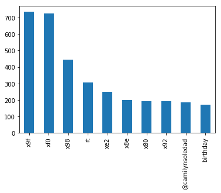

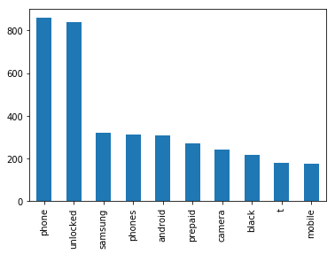

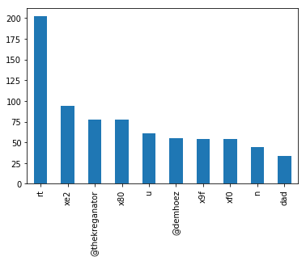

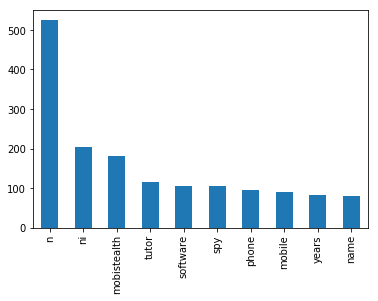

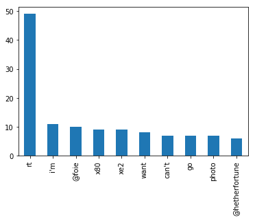

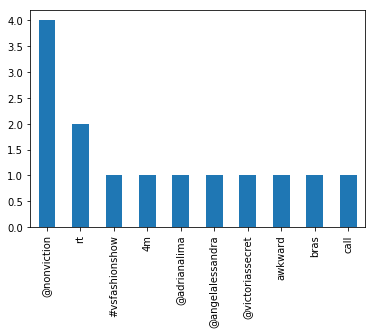

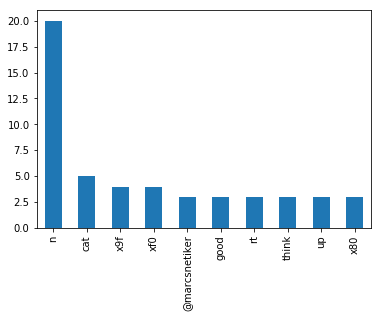

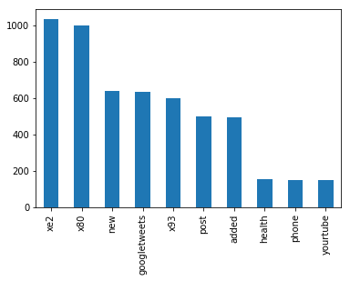

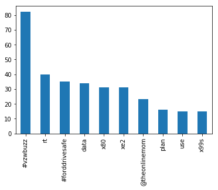

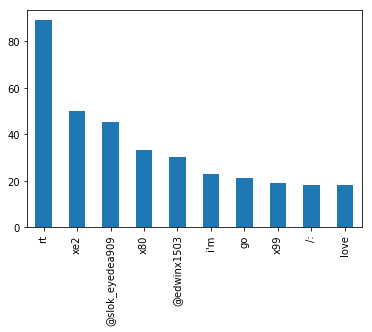

```python
for i in range(0,10):
    vis = dictionaryUsersWithCount[i].head(10)
    #print(vis)
    vis['Count'].plot(kind='bar')
    plt.show()
```

Once you have the dictionary for each user, write a method that when called and given a twitter handle, would be able to rank the other 9 users based on their similarity to the given user.

**Calculating the Similarity**

```python
#using a dictionary and converting dataframes to dictionaries
dictionaryUsers = {}
for i in range(0,10):
    dictionaryUsers['U'+str(i+1)] = (dictionaryUsersWithCount[i].to_dict()["Count"])
```

Defining the Methods to measure the Cosine similarity of Vectors

```python
import numpy as np
def cos_sim(a,b):
    dot_product = np.dot(a,b)
    norm_a = np.linalg.norm(a)
    norm_b = np.linalg.norm(b)
    return dot_product/(norm_a * norm_b)
```

```python
def calculateSimilarity(dict1,dict2):
    all_words_list = []
    for key in dict1:
        all_words_list.append(key)
    for key in dict2:
        all_words_list.append(key)
    all_words_list_size = len(all_words_list)
    #all_words_list_size
    v1 = np.zeros(all_words_list_size, dtype=np.int)
    v2 = np.zeros(all_words_list_size, dtype=np.int)
    i = 0
    for(key) in all_words_list:
        v1[i] = dict1.get(key,0)
        v2[i] = dict2.get(key,0)
        i = i +1
    return cos_sim(v1,v2)
```

Simple example to test Similarity using the functions defined above

```python
dict1 = {'sape': 4139, 'hello':1,'guido': 4127, 'jack': 4098}
dict2 = {'sape': 4139, 'guido': 4127, 'jack': 4098}
calculateSimilarity(dict1,dict2)
```

```
0.9999999950939078
```

Defining a method which when called and given a twitter handle, would be able to rank the other 9 users based on their similarity to the given user.

```python
def MainMethod(user,dicts):
    keys = list(dicts.keys())
    keys9 = [k for k in keys if not k in [user]]
    output = {}
    for k in keys9:
        output[k] = calculateSimilarity(dictionaryUsers[user],dictionaryUsers[k])
    return output
```

Calling the Main Method

```python
output = MainMethod('U6',dictionaryUsers)
for k in sorted(output, key=output.get, reverse=True):
    print(k,"  ",output[k])
```

```
U10    0.360633505022
U3    0.360458451793
U5    0.338573767212
U9    0.241216495182
U7    0.224564997683
U8    0.168068084335
U1    0.165708572822
U4    0.140786484424
U2    0.00160609157229
```